# Linear Models in R

Data Science for the Psychological Sciences

Paul D. Kieffaber, Ph.D.

# Introduction to Statistical Modeling

- **Goal:** Understand and explain relationships between variables.
- **Statistical modeling** = representing data through mathematical equations
  - Quantify relationships.
  - Identify patterns.
  - Make predictions.
- **Benefits:**
  - Simplifies complex systems (think Occam’s Razor).
  - Analyzes effects of multiple variables simultaneously.
  - Accounts for random variation and uncertainty.

# The Foundation: Simple Linear Regression

- **Fundamental Question:** How does a continuous outcome variable (Y) change as a continuous predictor variable (X) changes?
  - **Goal:** Find the single straight line that *best* describes the trend in our data.

### The Model

$$Y_i = \beta_0 + \beta_1X_i +
\epsilon_i$$

- $Y_i$ (Outcome): The dependent variable for observation *i*.
- $X_i$ (Predictor): The independent variable for observation *i*.
- $\beta_0$ (Intercept): The value of $Y$ when $X$ is 0 (y-axis intercept).
- $\beta_1$ (Slope): The change in $Y$ for a one-unit change in $X$.
- $\epsilon_i$ (Error/Residual): The unexplained variance; the vertical distance from the data point to the line.

**Our goal is to plug in our X and Y data, then find the best estimates for** $\beta_0$ and $\beta_1$.

# How Do We Find the “Best” Estimates?

- **Ordinary Least Squares (OLS)** finds the “best” line by minimizing the total error.
- **OLS Goal:** Find the values of $\beta_0$ and $\beta_1$ that *minimize the sum of the squared residuals (RSS)*.

$$RSS = \sum_{i=1}^{n} \epsilon\_i^2 =
\sum_{i=1}^{n} (Y_i - (\beta_0 + \beta_1X_i))^2$$

- Think of $\sum$ like a “for loop”
- **Minimizing Error:**
  - Error terms ($\epsilon_i$) can be positive or negative, canceling each other out.
  - Thus, we **Square** each error. This makes all errors positive and heavily penalizes large mistakes.
- Visualizing OLS:
  - **Blue points:** Raw data ($Y_i$)
  - **Red line:** The OLS regression line ($\hat{Y}$)
  - **Dashed lines:** The residuals ($\epsilon_i$) that OLS minimizes.

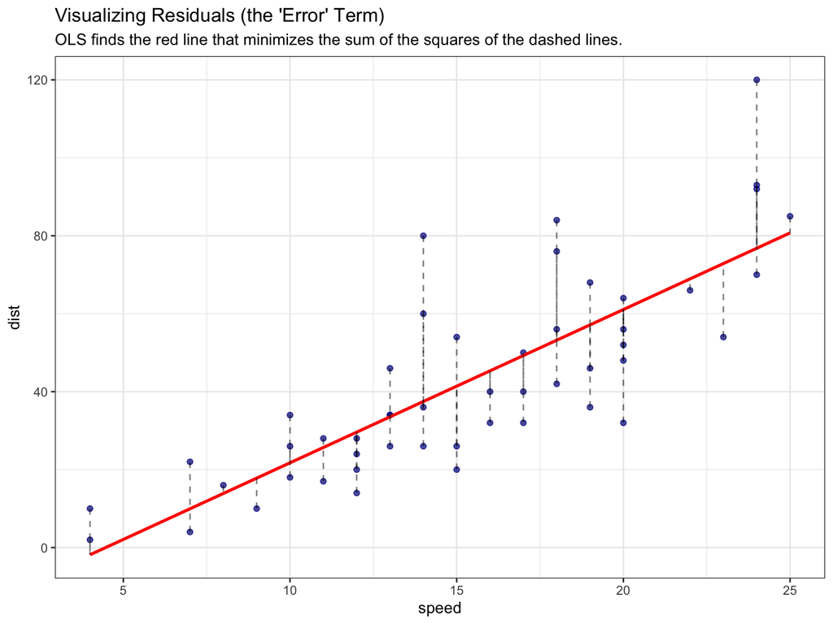

```r
# Use the built-in 'cars' dataset
data(cars)

# 1. Run the linear model
model_cars <- lm(dist ~ speed, data = cars)

# 2. Use broom::augment() to get model results
model_aug <- broom::augment(model_cars)

# 3. Plot the data, the line, and the residuals
ggplot(model_aug, aes(x = speed, y = dist)) +
  geom_point(color = "darkblue", alpha = 0.7) +  # The raw data points (Y_i)
  geom_smooth(method = "lm", se = FALSE, color = "red") + # The regression line (Y_hat)
  geom_segment(
    aes(xend = speed, yend = .fitted),
    color = "black",
    alpha = 0.5,
    linetype = "dashed"
  ) + # The residuals (epsilon_i)
  labs(
    title = "Visualizing Residuals (the 'Error' Term)",
    subtitle = "OLS finds the red line that minimizes the sum of the squares of the dashed lines."
  ) +
  theme_bw()
```

# OLS: The Model Parameters

1. The Slope ($\beta_1$):
- The covariance of X and Y divided by the variance of X.
- Measures how much Y changes, on average, for each one-unit change in X.
  $$\beta_1 = \frac{\text{Cov}(X,
  Y)}{\text{Var}(X)} = \frac{\frac{\sum_{i=1}^{n} (X_i - \bar{X})(Y_i -
  \bar{Y})}{n - 1}}{\frac{\sum_{i=1}^{n} (X_i - \bar{X})^2}{n - 1}}$$
2. The Intercept ($\beta_0$):
- Calculated to ensure the line passes through the “center of mass” of the data: $(\bar{X}, \bar{Y})$.
  $$\beta_0 = \bar{Y} - \beta_1\bar{X}$$

# R Implementation: `lm()`

- `lm()` (linear model) function.
- The formula `dist ~ speed` means stopping distance, “dist”, is modeled as a function of “speed”.
- `summary()` provides detailed results.

```r
model_cars <- lm(dist ~ speed, data = cars)

# Use summary() to get the detailed results
summary(model_cars)
```

```
##
## Call:
## lm(formula = dist ~ speed, data = cars)
##
## Residuals:
##     Min      1Q  Median      3Q     Max
## -29.069  -9.525  -2.272   9.215  43.201
##
## Coefficients:
##             Estimate Std. Error t value Pr(>|t|)
## (Intercept) -17.5791     6.7584  -2.601   0.0123 *
## speed         3.9324     0.4155   9.464 1.49e-12 ***
## ---
## Signif. codes:  0 '***' 0.001 '**' 0.01 '*' 0.05 '.' 0.1 ' ' 1
##
## Residual standard error: 15.38 on 48 degrees of freedom
## Multiple R-squared:  0.6511, Adjusted R-squared:  0.6438
## F-statistic: 89.57 on 1 and 48 DF,  p-value: 1.49e-12
```

- **Null Hypothesis (**$H_0$): There is no relationship.
  - $H_0: \beta_1 = 0$
- **Alternative Hypothesis (**$H_a$): There is a relationship.
  - $H_a: \beta_1 \neq 0$
- Reading the `summary()`
  - **Coefficients Table:**
    - `(Intercept)`: $\beta_0 = -17.58$.
    - The *predicted* stopping distance at 0 mph.
    - Often not practically meaningful, but mathematically necessary.
  - `speed` (Estimate): $\beta_1 = 3.93$.
    - **The key result!** For every 1 mph increase in speed, stopping distance increases by 3.93 ft.
    - `Pr(>|t|)` (p-value): Tests the null hypothesis.
- **Conclusion:**
  - We reject the null hypothesis.
  - There is a statistically significant positive linear relationship between speed and stopping distance.

# Visualizing the Results of Linear Regression

- `geom_smooth(method = "lm")` runs the *exact same* OLS regression and plots the line.
- The shaded area is the 95% confidence interval.

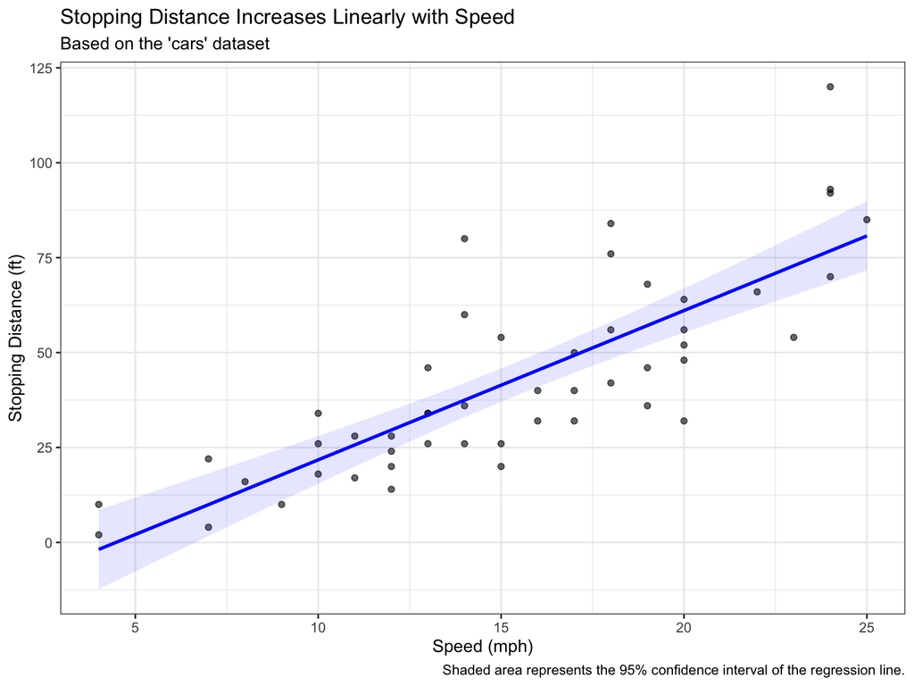

```r
ggplot(cars, aes(x = speed, y = dist)) +
  geom_point(alpha = 0.6) +
  geom_smooth(method = "lm", color = "blue", fill = "blue", alpha = 0.1) +
  labs(
    title = "Stopping Distance Increases Linearly with Speed",
    subtitle = "Based on the 'cars' dataset",
    x = "Speed (mph)",
    y = "Stopping Distance (ft)",
    caption = "Shaded area represents the 95% confidence interval of the regression line."
  ) +
  theme_bw()
```

# The t-test is also a Regression

- **Concept:** A t-test is not a separate tool; it is a special case of the General Linear Model.
- **Proof:** Running a t-test is mathematically identical to running a regression with a single, two-level categorical predictor.
- **T-test Question:** Is the mean of a continuous variable (Y) different between two groups (A and B)?
  - **T-test Hypothesis:**
  - $H_0: \mu_A = \mu_B$
  - $H_a: \mu_A \neq \mu_B$

# The t-test: The Conceptual Link

- **Regression Model:** $Y_i = \beta_0 + \beta_1X_i + \epsilon_i$
  - **The Problem:** How do we use a *categorical* predictor (e.g., “Group A”, “Group B”) as $X$?
  - **The Solution: Dummy Coding**
1. **Reference Group:** R picks one level as the “reference” (e.g., “Group A”) and assigns it **0**.
2. **Contrast Group:** The other level (“Group B”) gets a **1**.
- This creates a new numeric variable, $X_{dummy}$.

# The t-test: Dummy Coding in the Model

- **Case 1: A person in “Group A” (**$X_{dummy} = 0$)
  - $Y_i = \beta_0 + \beta_1(0) + \epsilon_i$
  - $Y_i = \beta_0 + \epsilon_i$
  - **Conclusion:** $\beta_0$ (the intercept) is the mean of the reference group (Group A).
  - $\beta_0 = \mu_A$
- **Case 2: A person in “Group B” (**$X_{dummy} = 1$)
  - $Y_i = \beta_0 + \beta_1(1) + \epsilon_i$
  - $Y_i = (\beta_0 + \beta_1) + \epsilon_i$
  - $(\beta_0 + \beta_1) = \mu_B$
  - We know $\beta_0 = \mu_A$, so: $\mu_B = \mu_A + \beta_1$
  - **Conclusion:** $\beta_1$ (the slope) is the *difference* between the mean of Group B and the mean of Group A.
  - $\beta_1 = \mu_B - \mu_A$